# Pipelines to analyze SLE Cut&Run and RNA-seq data

## Data from all three conditions in ELF1

The steps performed above were used in an R script file to be performed with the other two conditions. Below I will load all the .tsv files that contain the genes from every condition that passed the p adjusted value thresholds.

I want to make a venn diagram to see if any of the genes found in the three conditions are shared, and if there are unique genes found in each condition. I do expect to see the ELF1 gene shared amonst all three conditions MOCK, IAV, BLEOMYCIN.

```r
# i want to load in all the other genes found from the other conditions

getwd()

mock_data = read.csv(file = '../rna_seq_data//ELF1_mock_data//de_genes_lfc_shrunk_padj.tsv', sep = '\t', header = TRUE)
iav_data = read.csv(file = '../rna_seq_data//ELF1_iav_data//de_genes_lfc_shrunk_padj.tsv', sep = '\t', header = TRUE)
bleo_data =  read.csv(file = '../rna_seq_data//ELF1_bleomycin_data/de_genes_lfc_shrunk_padj.tsv', sep = '\t', header = TRUE)

mock_data
length(mock_data[,1])
```

'D:/tf_sle_Jacopo_project/nextflow_pipeline_rnaseq'

A data.frame: 49 × 6

| genes <chr> | baseMean <dbl> | log2FoldChange <dbl> | lfcSE <dbl> | pvalue <dbl> | padj <dbl> |
| --- | --- | --- | --- | --- | --- |
| RIMKLA | 46.384241 | -0.5996264 | 0.18771126 | 5.394070e-05 | 1.356772e-02 |
| MR1 | 130.843683 | -0.5496280 | 0.11476316 | 8.112417e-08 | 1.496380e-04 |
| PSD4 | 51.351690 | -0.5956900 | 0.21707916 | 2.236357e-04 | 3.375070e-02 |
| HNMT | 7.378372 | -1.9269808 | 0.51742924 | 1.416745e-05 | 5.879847e-03 |
| ABCA12 | 82.299549 | -0.5217054 | 0.20647856 | 3.729200e-04 | 4.654771e-02 |
| ZPLD1 | 6.647045 | 1.5733870 | 0.52914284 | 1.204246e-04 | 2.379963e-02 |
| RAB6B | 34.538427 | 0.7032144 | 0.26540969 | 2.699295e-04 | 3.734249e-02 |
| MECOM | 15.514699 | -1.4828979 | 0.33776982 | 5.336451e-07 | 6.160593e-04 |
| ZMAT3 | 115.448606 | -0.6252405 | 0.21856923 | 1.569253e-04 | 2.742229e-02 |
| GASK1B-AS1 | 7.645170 | 3.5948560 | 0.71012013 | 4.720525e-08 | 9.795679e-05 |
| FCHSD1 | 73.059075 | -0.6777601 | 0.17192489 | 3.693335e-06 | 2.452522e-03 |
| ANXA6 | 322.962806 | 0.6283116 | 0.09812438 | 7.049076e-12 | 3.900724e-08 |
| ADRA1B | 67.283867 | 0.6424083 | 0.24699547 | 3.047209e-04 | 4.112741e-02 |
| ENSG00000231683 | 26.962218 | -1.2022670 | 0.27762843 | 5.566465e-07 | 6.160593e-04 |
| EPHA7 | 63.075687 | 0.6188359 | 0.22286658 | 1.680690e-04 | 2.838092e-02 |
| CLDN4 | 59.352992 | -0.5592299 | 0.22963313 | 4.111589e-04 | 4.875464e-02 |
| ARHGEF5 | 102.810398 | -0.5565424 | 0.16786293 | 3.214196e-05 | 1.066317e-02 |
| NUDT18 | 60.406388 | -0.6786986 | 0.17775620 | 4.977158e-06 | 3.101701e-03 |
| CTSV | 104.504836 | 0.6764013 | 0.12989847 | 7.996298e-09 | 2.212442e-05 |
| TBC1D2 | 73.200374 | -0.9413999 | 0.23511491 | 2.694312e-06 | 1.944707e-03 |
| MAP3K8 | 82.161986 | 0.5150746 | 0.16566039 | 7.534788e-05 | 1.737292e-02 |
| ANXA8L1 | 44.693009 | -0.7880796 | 0.21185025 | 8.596263e-06 | 4.459580e-03 |
| OLMALINC | 73.050694 | 0.5135730 | 0.19019997 | 2.542764e-04 | 3.607899e-02 |
| EHF | 49.435667 | -0.8779909 | 0.32502287 | 1.966821e-04 | 3.131078e-02 |
| GRIA4 | 5.585118 | -4.3213894 | 1.01561793 | 3.005609e-07 | 3.838162e-04 |
| SLC6A13 | 5.776968 | 3.0929023 | 0.76511418 | 2.935300e-06 | 2.030371e-03 |
| IRAK4 | 117.734557 | -0.7247274 | 0.13300729 | 2.261777e-09 | 9.386942e-06 |
| ELF1 | 239.631035 | -1.8895538 | 0.13843564 | 1.086540e-43 | 1.803765e-39 |
| PCDH17 | 10.499612 | 1.9374071 | 0.58498644 | 3.731852e-05 | 1.074139e-02 |
| SLC27A2 | 253.704960 | -0.5286707 | 0.17675915 | 9.417327e-05 | 2.013027e-02 |
| ITGAX | 15.297256 | -2.4633378 | 0.37401516 | 3.601771e-12 | 2.989650e-08 |
| FAM171A2 | 32.584516 | 0.6955154 | 0.21127914 | 3.817493e-05 | 1.074139e-02 |
| WIPI1 | 54.617828 | -0.6322675 | 0.17139055 | 9.264696e-06 | 4.498908e-03 |
| SECTM1 | 5.769240 | -2.9918808 | 0.67747325 | 1.725568e-06 | 1.364102e-03 |
| LSR | 130.201412 | -0.8660443 | 0.17343984 | 2.053232e-08 | 4.869385e-05 |
| ZFP82 | 51.733892 | 0.5959049 | 0.23266064 | 3.227737e-04 | 4.285758e-02 |
| ZNF529-AS1 | 24.941565 | 0.7197590 | 0.25331829 | 1.461193e-04 | 2.629275e-02 |
| MYH14 | 207.395213 | 0.5042680 | 0.12224704 | 1.679588e-06 | 1.364102e-03 |
| ZNF542P | 63.424625 | 0.8422374 | 0.19418482 | 6.485131e-07 | 6.728729e-04 |
| ZNF256 | 19.005602 | 0.9043856 | 0.26599125 | 2.601392e-05 | 9.596823e-03 |
| ZSCAN18 | 26.635878 | 0.6563692 | 0.24505935 | 2.362954e-04 | 3.441000e-02 |
| ENSG00000286472 | 9.324220 | 3.9393377 | 0.85140644 | 2.650439e-07 | 3.666661e-04 |
| MYH7B | 14.780800 | 3.0282978 | 1.07382080 | 1.387764e-04 | 2.537149e-02 |
| SLPI | 69.808473 | -0.6502657 | 0.18122898 | 1.355107e-05 | 5.768238e-03 |
| LINC01273 | 27.919494 | 0.7335774 | 0.23382426 | 6.104082e-05 | 1.468607e-02 |
| MAGEB2 | 22.850484 | 1.0326274 | 0.39684444 | 2.460010e-04 | 3.520571e-02 |
| MAGEE1 | 61.214443 | 0.5763773 | 0.16217620 | 1.496085e-05 | 5.913453e-03 |
| FAM133A | 45.408547 | 0.8074589 | 0.21995903 | 9.756080e-06 | 4.498908e-03 |
| MT-TS1 | 69.737020 | 0.7669248 | 0.16541682 | 1.759032e-07 | 2.920168e-04 |

49

```r
# i need to first take the first column of all three conditions and only place unique genes from each into a new list

list_of_genes = NULL

list_of_genes = append(list_of_genes, mock_data[,1])#, bleo_data[,1], iav_data[,1])
list_of_genes = append(list_of_genes, bleo_data[,1])
list_of_genes = append(list_of_genes, iav_data[,1])
list_of_genes

length(list_of_genes)

unique_genes = NULL

# i want to avoid copies of the same gene
for (x in c(1:length(list_of_genes))){
    if (!list_of_genes[x] %in% unique_genes) unique_genes = append(unique_genes, list_of_genes[x])
}

unique_genes

length(unique_genes)

# so now I can build a data frame that has the unique genes and three empty columns, one for each condition

condition_df = data.frame( unique_genes, mock = NA, IAV = NA, bleo = NA)

# this data frame will be the basis where I create a venn diagram from.
# using ggvenn package
# this package only takes logical entries
condition_df
```

1. 'RIMKLA'

2. 'MR1'

3. 'PSD4'

4. 'HNMT'

5. 'ABCA12'

6. 'ZPLD1'

7. 'RAB6B'

8. 'MECOM'

9. 'ZMAT3'

10. 'GASK1B-AS1'

11. 'FCHSD1'

12. 'ANXA6'

13. 'ADRA1B'

14. 'ENSG00000231683'

15. 'EPHA7'

16. 'CLDN4'

17. 'ARHGEF5'

18. 'NUDT18'

19. 'CTSV'

20. 'TBC1D2'

21. 'MAP3K8'

22. 'ANXA8L1'

23. 'OLMALINC'

24. 'EHF'

25. 'GRIA4'

26. 'SLC6A13'

27. 'IRAK4'

28. 'ELF1'

29. 'PCDH17'

30. 'SLC27A2'

31. 'ITGAX'

32. 'FAM171A2'

33. 'WIPI1'

34. 'SECTM1'

35. 'LSR'

36. 'ZFP82'

37. 'ZNF529-AS1'

38. 'MYH14'

39. 'ZNF542P'

40. 'ZNF256'

41. 'ZSCAN18'

42. 'ENSG00000286472'

43. 'MYH7B'

44. 'SLPI'

45. 'LINC01273'

46. 'MAGEB2'

47. 'MAGEE1'

48. 'FAM133A'

49. 'MT-TS1'

50. 'TNFRSF9'

51. 'COL11A1'

52. 'FLG'

53. 'SP110'

54. 'GRIP2'

55. 'CXCL1'

56. 'CXCL2'

57. 'RNF150'

58. 'TLR2'

59. 'GASK1B-AS1'

60. 'NDST1-AS1'

61. 'TRIM31'

62. 'ROS1'

63. 'ADGRA2'

64. 'LRRCC1'

65. 'CSMD3'

66. 'PTP4A3'

67. 'GALNT12'

68. 'ANXA8L1'

69. 'CYB5R2'

70. 'TUB'

71. 'IRAK4'

72. 'ELF1'

73. 'CKMT1A'

74. 'C15orf48'

75. 'CGNL1'

76. 'HAPLN3'

77. 'IL32'

78. 'TMEM102'

79. 'KRBA2'

80. 'NTN1'

81. 'RAB11FIP4'

82. 'WIPI1'

83. 'LINC01836'

84. 'ICAM1'

85. 'DBNDD2'

86. 'KREMEN1'

87. 'SYP'

88. 'ENSG00000275110'

89. 'PDZD4'

90. 'MR1'

91. 'ENSG00000230199'

92. 'THUMPD3-AS1'

93. 'ST3GAL1'

94. 'ELF1'

95. 'NID2'

96. 'APOL6'

96

1. 'RIMKLA'

2. 'MR1'

3. 'PSD4'

4. 'HNMT'

5. 'ABCA12'

6. 'ZPLD1'

7. 'RAB6B'

8. 'MECOM'

9. 'ZMAT3'

10. 'GASK1B-AS1'

11. 'FCHSD1'

12. 'ANXA6'

13. 'ADRA1B'

14. 'ENSG00000231683'

15. 'EPHA7'

16. 'CLDN4'

17. 'ARHGEF5'

18. 'NUDT18'

19. 'CTSV'

20. 'TBC1D2'

21. 'MAP3K8'

22. 'ANXA8L1'

23. 'OLMALINC'

24. 'EHF'

25. 'GRIA4'

26. 'SLC6A13'

27. 'IRAK4'

28. 'ELF1'

29. 'PCDH17'

30. 'SLC27A2'

31. 'ITGAX'

32. 'FAM171A2'

33. 'WIPI1'

34. 'SECTM1'

35. 'LSR'

36. 'ZFP82'

37. 'ZNF529-AS1'

38. 'MYH14'

39. 'ZNF542P'

40. 'ZNF256'

41. 'ZSCAN18'

42. 'ENSG00000286472'

43. 'MYH7B'

44. 'SLPI'

45. 'LINC01273'

46. 'MAGEB2'

47. 'MAGEE1'

48. 'FAM133A'

49. 'MT-TS1'

50. 'TNFRSF9'

51. 'COL11A1'

52. 'FLG'

53. 'SP110'

54. 'GRIP2'

55. 'CXCL1'

56. 'CXCL2'

57. 'RNF150'

58. 'TLR2'

59. 'NDST1-AS1'

60. 'TRIM31'

61. 'ROS1'

62. 'ADGRA2'

63. 'LRRCC1'

64. 'CSMD3'

65. 'PTP4A3'

66. 'GALNT12'

67. 'CYB5R2'

68. 'TUB'

69. 'CKMT1A'

70. 'C15orf48'

71. 'CGNL1'

72. 'HAPLN3'

73. 'IL32'

74. 'TMEM102'

75. 'KRBA2'

76. 'NTN1'

77. 'RAB11FIP4'

78. 'LINC01836'

79. 'ICAM1'

80. 'DBNDD2'

81. 'KREMEN1'

82. 'SYP'

83. 'ENSG00000275110'

84. 'PDZD4'

85. 'ENSG00000230199'

86. 'THUMPD3-AS1'

87. 'ST3GAL1'

88. 'NID2'

89. 'APOL6'

89

A data.frame: 89 × 4

| unique_genes <chr> | mock <lgl> | IAV <lgl> | bleo <lgl> |
| --- | --- | --- | --- |
| RIMKLA | NA | NA | NA |
| MR1 | NA | NA | NA |
| PSD4 | NA | NA | NA |
| HNMT | NA | NA | NA |
| ABCA12 | NA | NA | NA |
| ZPLD1 | NA | NA | NA |
| RAB6B | NA | NA | NA |
| MECOM | NA | NA | NA |
| ZMAT3 | NA | NA | NA |
| GASK1B-AS1 | NA | NA | NA |
| FCHSD1 | NA | NA | NA |
| ANXA6 | NA | NA | NA |
| ADRA1B | NA | NA | NA |
| ENSG00000231683 | NA | NA | NA |
| EPHA7 | NA | NA | NA |
| CLDN4 | NA | NA | NA |
| ARHGEF5 | NA | NA | NA |
| NUDT18 | NA | NA | NA |
| CTSV | NA | NA | NA |
| TBC1D2 | NA | NA | NA |
| MAP3K8 | NA | NA | NA |
| ANXA8L1 | NA | NA | NA |
| OLMALINC | NA | NA | NA |
| EHF | NA | NA | NA |
| GRIA4 | NA | NA | NA |
| SLC6A13 | NA | NA | NA |
| IRAK4 | NA | NA | NA |
| ELF1 | NA | NA | NA |
| PCDH17 | NA | NA | NA |
| SLC27A2 | NA | NA | NA |
| ⋮ | ⋮ | ⋮ | ⋮ |
| TRIM31 | NA | NA | NA |
| ROS1 | NA | NA | NA |
| ADGRA2 | NA | NA | NA |
| LRRCC1 | NA | NA | NA |
| CSMD3 | NA | NA | NA |
| PTP4A3 | NA | NA | NA |
| GALNT12 | NA | NA | NA |
| CYB5R2 | NA | NA | NA |
| TUB | NA | NA | NA |
| CKMT1A | NA | NA | NA |
| C15orf48 | NA | NA | NA |
| CGNL1 | NA | NA | NA |
| HAPLN3 | NA | NA | NA |
| IL32 | NA | NA | NA |
| TMEM102 | NA | NA | NA |
| KRBA2 | NA | NA | NA |
| NTN1 | NA | NA | NA |
| RAB11FIP4 | NA | NA | NA |
| LINC01836 | NA | NA | NA |
| ICAM1 | NA | NA | NA |
| DBNDD2 | NA | NA | NA |
| KREMEN1 | NA | NA | NA |
| SYP | NA | NA | NA |
| ENSG00000275110 | NA | NA | NA |
| PDZD4 | NA | NA | NA |
| ENSG00000230199 | NA | NA | NA |
| THUMPD3-AS1 | NA | NA | NA |
| ST3GAL1 | NA | NA | NA |
| NID2 | NA | NA | NA |
| APOL6 | NA | NA | NA |

```r
# now to populate the data frame

# mock_data
# iav_data
# bleo_data[,1]
# condition_df
#condition_df[1,1] %in% bleo_data[,1]

'FLG' %in% condition_df[,1]

for (x in c(1:length(condition_df[,1]))) {
    if (condition_df[x,1] %in% mock_data[,1]) condition_df[x,2] = 1 else condition_df[x,2] = 0
    if (condition_df[x,1] %in% iav_data[,1]) condition_df[x,3] = 1 else condition_df[x,3] = 0
    if (condition_df[x,1] %in% bleo_data[,1]) condition_df[x,4] = 1 else condition_df[x,4] = 0
}


# I want to use lapply to make the 0's and 1's into logical values.
# this way ggvenn can make a venn diagram

logical_data_conditions = data.frame(lapply(condition_df[,c(2:4)],as.logical))

condition_logical_df = cbind(unique_genes = condition_df[,1], logical_data_conditions)

# this will be the variable I place into ggven
condition_logical_df
```

TRUE

A data.frame: 89 × 4

| unique_genes <chr> | mock <lgl> | IAV <lgl> | bleo <lgl> |
| --- | --- | --- | --- |
| RIMKLA | TRUE | FALSE | FALSE |
| MR1 | TRUE | TRUE | FALSE |
| PSD4 | TRUE | FALSE | FALSE |
| HNMT | TRUE | FALSE | FALSE |
| ABCA12 | TRUE | FALSE | FALSE |
| ZPLD1 | TRUE | FALSE | FALSE |
| RAB6B | TRUE | FALSE | FALSE |
| MECOM | TRUE | FALSE | FALSE |
| ZMAT3 | TRUE | FALSE | FALSE |
| GASK1B-AS1 | TRUE | FALSE | TRUE |
| FCHSD1 | TRUE | FALSE | FALSE |
| ANXA6 | TRUE | FALSE | FALSE |
| ADRA1B | TRUE | FALSE | FALSE |
| ENSG00000231683 | TRUE | FALSE | FALSE |
| EPHA7 | TRUE | FALSE | FALSE |
| CLDN4 | TRUE | FALSE | FALSE |
| ARHGEF5 | TRUE | FALSE | FALSE |
| NUDT18 | TRUE | FALSE | FALSE |
| CTSV | TRUE | FALSE | FALSE |
| TBC1D2 | TRUE | FALSE | FALSE |
| MAP3K8 | TRUE | FALSE | FALSE |
| ANXA8L1 | TRUE | FALSE | TRUE |
| OLMALINC | TRUE | FALSE | FALSE |
| EHF | TRUE | FALSE | FALSE |
| GRIA4 | TRUE | FALSE | FALSE |
| SLC6A13 | TRUE | FALSE | FALSE |
| IRAK4 | TRUE | FALSE | TRUE |
| ELF1 | TRUE | TRUE | TRUE |
| PCDH17 | TRUE | FALSE | FALSE |
| SLC27A2 | TRUE | FALSE | FALSE |
| ⋮ | ⋮ | ⋮ | ⋮ |
| TRIM31 | FALSE | FALSE | TRUE |
| ROS1 | FALSE | FALSE | TRUE |
| ADGRA2 | FALSE | FALSE | TRUE |
| LRRCC1 | FALSE | FALSE | TRUE |
| CSMD3 | FALSE | FALSE | TRUE |
| PTP4A3 | FALSE | FALSE | TRUE |
| GALNT12 | FALSE | FALSE | TRUE |
| CYB5R2 | FALSE | FALSE | TRUE |
| TUB | FALSE | FALSE | TRUE |
| CKMT1A | FALSE | FALSE | TRUE |
| C15orf48 | FALSE | FALSE | TRUE |
| CGNL1 | FALSE | FALSE | TRUE |
| HAPLN3 | FALSE | FALSE | TRUE |
| IL32 | FALSE | FALSE | TRUE |
| TMEM102 | FALSE | FALSE | TRUE |
| KRBA2 | FALSE | FALSE | TRUE |
| NTN1 | FALSE | FALSE | TRUE |
| RAB11FIP4 | FALSE | FALSE | TRUE |
| LINC01836 | FALSE | FALSE | TRUE |
| ICAM1 | FALSE | FALSE | TRUE |
| DBNDD2 | FALSE | FALSE | TRUE |
| KREMEN1 | FALSE | FALSE | TRUE |
| SYP | FALSE | FALSE | TRUE |
| ENSG00000275110 | FALSE | FALSE | TRUE |
| PDZD4 | FALSE | FALSE | TRUE |
| ENSG00000230199 | FALSE | TRUE | FALSE |
| THUMPD3-AS1 | FALSE | TRUE | FALSE |
| ST3GAL1 | FALSE | TRUE | FALSE |
| NID2 | FALSE | TRUE | FALSE |
| APOL6 | FALSE | TRUE | FALSE |

```r
#install.packages('ggvenn')
```

**png:** 2

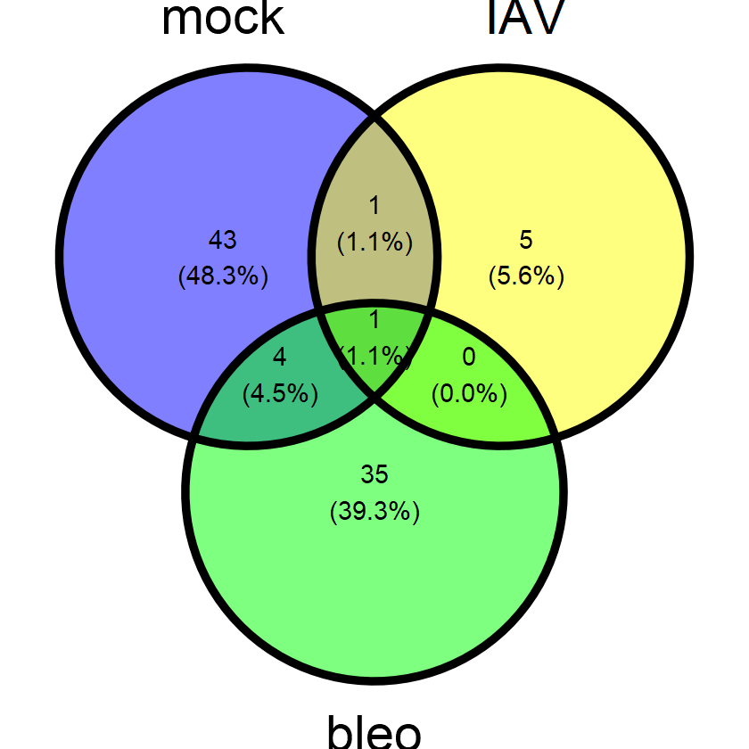

```r
library(ggvenn)
#?ggvenn

# These are the three conditions in the experiment using ELF1

ggvenn(condition_logical_df, c('mock', 'IAV', 'bleo'), stroke_size = 2, set_name_size = 12, text_size = 6)

png(file = 'venn_diagram_DE_genes.png', width = 1000, height = 1000)
ggvenn(condition_logical_df, c('mock', 'IAV', 'bleo'), stroke_size = 2, set_name_size = 12, text_size = 8)
dev.off()

# As you can see there is only one gene that is shared between all three conditions and that would be ELF1, which is expected.
# There is only one gene shared between IAV and mock, and there are four genes shared between mock and bleomycin.
# There are zero genes shared between IAV and bleomycin
```

**png:** 2

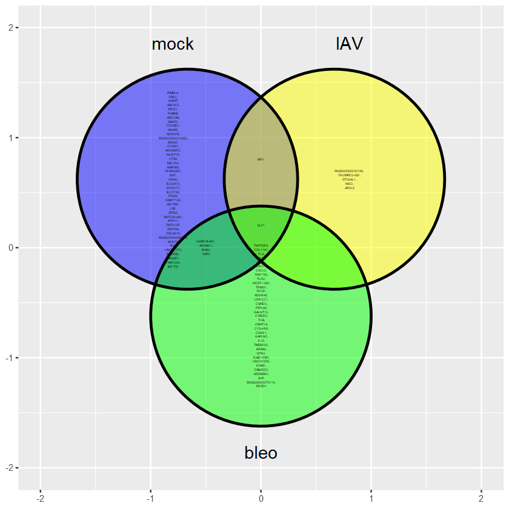

```r
#?ggvenn
#?geom_venn
#?title
#?coord_fixed
#?legend

# I looked for a way to get the names of the genes into the venn diagram. the label option helps with this
# We can only see the intersection genes clearly in the venn diagram which is fine
# we already have a list of all genes in each condition.
# It may be benificial to quickly know which genes appear in the intercection regions

ggplot(condition_logical_df) + geom_venn(aes(A = mock, B = IAV, C = bleo, label = unique_genes), label_sep = ',\n ', text_size = 1)

png(file = 'venn_diagram_DE_genes_labels.png', width = 1000, height = 1000)
ggplot(condition_logical_df) + geom_venn(aes(A = mock, B = IAV, C = bleo, label = unique_genes), label_sep = ',\n ', text_size = 2)
dev.off()
```

```r
#?geom_venn
?ggplot
```

**png:** 2

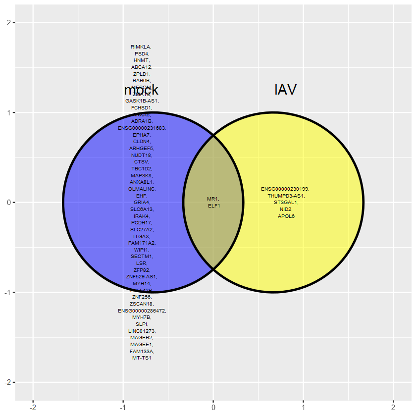

```r
# this is to show the names found in each condition more clearly
ggplot(condition_logical_df) + geom_venn(aes(A = mock, B = IAV, label = unique_genes), label_sep = ',\n ', text_size = 2, show_outside = 'none')

png(file = 'mock_vs_iav_venn.png', width = 1000, height = 1000)
ggplot(condition_logical_df) + geom_venn(aes(A = mock, B = IAV, label = unique_genes), label_sep = ',\n ', text_size = 4, show_outside = 'none')
dev.off()
```

**png:** 2

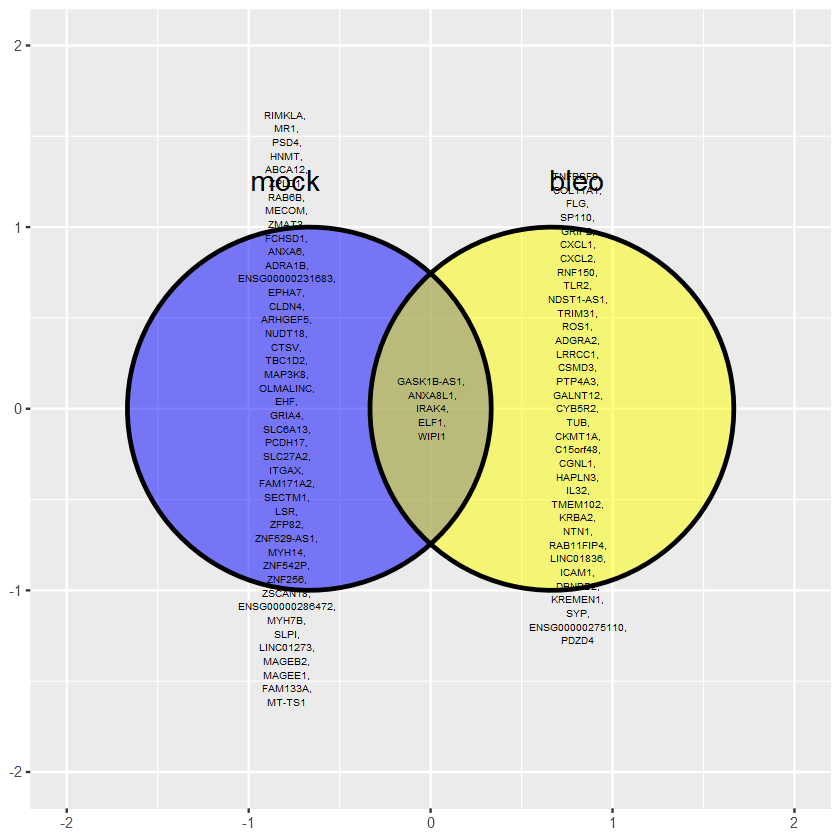

```r
ggplot(condition_logical_df) + geom_venn(aes(A = mock, B = bleo, label = unique_genes), label_sep = ',\n ', text_size = 2, show_outside = 'none')

png(file = 'mock_vs_bleo_venn.png', width = 1000, height = 1000)
ggplot(condition_logical_df) + geom_venn(aes(A = mock, B = bleo, label = unique_genes), label_sep = ',\n ', text_size = 4, show_outside = 'none')
dev.off()
```

**png:** 2

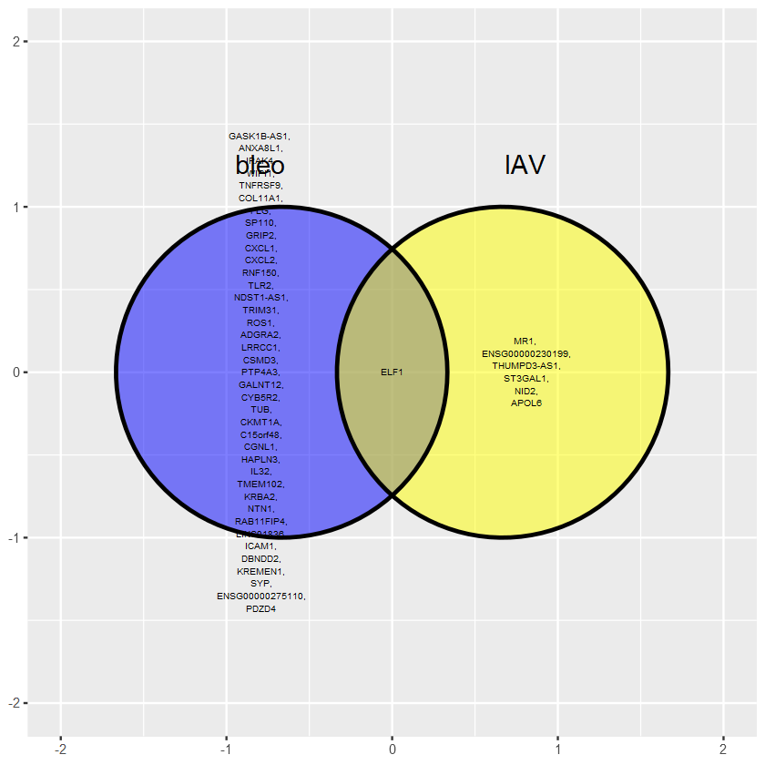

```r
ggplot(condition_logical_df) + geom_venn(aes(A = bleo, B = IAV, label = unique_genes), label_sep = ',\n ', text_size = 2, show_outside = 'none')

png(file = 'bleo_vs_iav_venn.png', width = 1000, height = 1000)
ggplot(condition_logical_df) + geom_venn(aes(A = bleo, B = IAV, label = unique_genes), label_sep = ',\n ', text_size = 4, show_outside = 'none')
dev.off()
```

As you can see there is only one gene that is shared between all three conditions and that would be ELF1, which is expected. There is only one gene shared between IAV and mock, and there are four genes shared between mock and bleomycin. There are zero genes shared between IAV and bleomycin

# nextflow config file for RNA-seq pipeline

As you can see this nextflow config file for my RNA-seq pipeline differs slightly from the Cut&Run config file. Here, I need to specify that there is a container that I am using in the process that needs it. Also I have to specify that the containers will be from singularityCE which is a module I need to load from the HPC. Now nextflow will know to run R from the container I created.

```r
// define the path to the reference file
//params.ref="/scratch/work/courses/BI7653/hw3.2023/hg38/Homo_sapiens.GRCh38.dna_sm.primary_assembly.normalized.fa"

//lets use our own human reference genome from ensembl. it isnt in fasta format appearently. just unzip it
//params.ref="/scratch/rj931/tf_sle_project/Homo_sapiens.GRCh38.dna.primary_assembly.fa"

// lets try the genome from gencode. just needed to be unzipped
params.ref="/scratch/rj931/tf_sle_project/GRCh38.primary_assembly.genome.fa"

//define the directory that contains the index files

params.dir_ref_files='/scratch/work/courses/BI7653/hw3.2023/hg38/'

// path to gtf file for star

// using this gtf file which came from ensembl. so now we cant use the ensembl gtf
//params.gtf="/scratch/rj931/tf_sle_project/Homo_sapiens.GRCh38.109.chr.gtf.gz"

// lets use the gencode gtf. appearently the gtf flies had to be unzipped also.
params.gtf="/scratch/rj931/tf_sle_project/test_this.gtf"

// define the path to the pair-end reads


params.input= []
//params.read_f=$read_f
//params.read_r=$read_r

// *_{1,2}*.fastq.gz


// define the path to the text containing the reads names

params.file_names="/scratch/work/courses/BI7653/hw2.2023/week2_fastqs.txt"


// define the executor and resources

process{
executor='slurm'
cpus=10
memory={15.GB*task.attempt}
time={30.min*task.attempt}
withName:fastp{time='1.h'}
withName:star{time='12.h'}
withName:star_align{time='12.h'}
withName:organize{time='3.h'}
withName:r_featurecounts {
time='12.h'
container = '/scratch/rj931/containers/r_container.sif'
}




//withName:bg_fastp{time='1.h'}
//withName:bg_bwa{time='3.h'}
}


process.module = "singularity-ce/3.11.0"
singularity.enabled = true
singularity.autoMounts = true
```

# Script to Run RNA-seq Pipeline files

This script below is how my RNA-seq pipeline will be ran. It is a normal slurm script that loads the nextflow module and runs the .nf file, which is the nextflow commands I showed above. with this pipeline everything is in nextflow except for the multiqc files that are generated. I generate those in the script that calls the nextflow pipeline.

```r
#!/bin/bash
#SBATCH --nodes=1
#SBATCH --ntasks-per-node=1
#SBATCH --cpus-per-task=1
#SBATCH --partition=cm
#SBATCH --time=10:00:00
#SBATCH --mem=10GB
#SBATCH --job-name=rna_pl
#SBATCH --mail-type=FAIL,END
#SBATCH --mail-user=rj931@nyu.edu
#SBATCH --output=slurm_%j.out


# need to change glob
# the mock condition is already part of the pipeline itself so if using you can use the glob pattern or just not use the command line
# parameters after calling nextflow run <pipeline.nf>

# mock glob pattern part of pipeline:  params.reads = "/scratch/rj931/tf_sle_project/all_sle_data/45*-Mock*polya*_{R1,R2}*.fastq.gz"
# mock glob pattern part of pipeline: params.filts = "filt_files/45*-Mock*polya*_{R1,R2}*.filt*"

# iav glob pattern for reads: "/scratch/rj931/tf_sle_project/all_sle_data/45*-IAV*polya*_{R1,R2}*.fastq.gz"
# iav glob pattern for filt files:  "filt_files/45*-IAV*polya*_{R1,R2}*.filt*"

# bleomycin glob pattern for reads:  "/scratch/rj931/tf_sle_project/all_sle_data/45*-Bleo*polya*_{R1,R2}*.fastq.gz"
# belomycin glob for filt files: "filt_files/45*-Bleo*polya*_{R1,R2}*.filt*"


module purge

module load nextflow/23.04.1

# i have to run this twice since the files are being created and sent to the dir
# so now that they exist the pipeline can move on, how to fix this and make it run
# or check the directories again instead

# replace the --reads parameter with the glob pattern for reads in the different condition
# replace the --filts parameter with the glob pattern for filt in the different condition
# examples are seen above

nextflow run -resume pe_rna_sle_pipeline.nf --reads "/scratch/rj931/tf_sle_project/all_sle_data/45*-IAV*polya*_{R1,R2}*.fastq.gz" \
--filts "filt_files/45*-IAV*polya*_{R1,R2}*.filt*"

nextflow run -resume pe_rna_sle_pipeline.nf --reads "/scratch/rj931/tf_sle_project/all_sle_data/45*-IAV*polya*_{R1,R2}*.fastq.gz" \
--filts "filt_files/45*-IAV*polya*_{R1,R2}*.filt*"



find . -name *fastqc.zip > fastqc_files.txt

module load multiqc/1.9

multiqc -force --file-list fastqc_files.txt --filename 'multiqc_report.html'

#nextflow run -resume pe_sle_pipeline.nf

# here i want to out put the genomic regions
# specify the path and the glob pattern for the --reads
# specify the the out dir for this set of filtered outputs
# specify the location of the bg filtered output fq files and the same glob pattern in the reads

#nextflow run -resume pe_sle_pipeline.nf \
#--reads "/scratch/rj931/tf_sle_project/all_sle_data/461-IgG*cut*_{R1,R2}*.fastq.gz" \
#--outdir "bg_filt" \
#--filts "bg_filt/461-IgG*cut*_{R1,R2}*.fastq.gz" \



# this section is to run the make_homer.sh script part of the pipeline

#sbatch make_homer.sh
```

# Next Steps

### Venn Diagram of CutRun results/ genes

```r
# first inport all of the differentially expressed peaks with genes
# annotated in them

mock_de_peaks = read.csv(file = '../elf1_Mock_CutRun_files/differential_peak_analysis//differential_mock_peaks_annotated_kd_vs_ctr.tsv', header = TRUE, sep = '\t')
iav_de_peaks = read.csv(file = '../elf1_IAV_CutRun_files/differential_peak_analysis//differential_iav_peaks_annotated_kd_vs_ctr.tsv', header = TRUE, sep = '\t')
bleo_de_peaks = read.csv(file= '../elf1_Bleo_CutRun_files/differential_peak_analysis//differential_bleo_peaks_annotated_kd_vs_ctr.tsv', header = TRUE, sep = '\t')

# just looking at the head of one of the files
head(mock_de_peaks,10)

# just looking at the column Gene.Name to see how i can get the individual gene names
head(mock_de_peaks$Gene.Name, 10)
```

A data.frame: 10 × 19

|  | PeakID..cmd.annotatePeaks.pl.outputPeaks_2.txt..scratch.rj931.tf_sle_project.GRCh38.primary_assembly.genome.fa..gtf..scratch.rj931.tf_sle_project.test_this.gtf. <chr> | Chr <chr> | Start <int> | End <int> | Strand <chr> | Peak.Score <dbl> | Focus.Ratio.Region.Size <dbl> | Annotation <chr> | Detailed.Annotation <chr> | Distance.to.TSS <int> | Nearest.PromoterID <chr> | Entrez.ID <chr> | Nearest.Unigene <chr> | Nearest.Refseq <lgl> | Nearest.Ensembl <lgl> | Gene.Name <chr> | Gene.Alias <lgl> | Gene.Description <lgl> | Gene.Type <chr> |
| --- | --- | --- | --- | --- | --- | --- | --- | --- | --- | --- | --- | --- | --- | --- | --- | --- | --- | --- | --- |
| 1 | chr7-1813 | chr7 | 49226896 | 49227022 | + | 3.70 | 0.733 | Intergenic | Intergenic | -3178 | ENST00000440455.1 | ENSG00000234686 | ENST00000440455 | NA | NA | ENSG00000234686 | NA | NA | lncRNA |
| 2 | chr12-2866 | chr12 | 105900814 | 105900940 | + | 3.57 | 0.725 | Intergenic | Intergenic | -115020 | ENST00000546640.1 | ENSG00000257773 | ENST00000546640 | NA | NA | ST13P3 | NA | NA | processed_pseudogene |
| 3 | chr8-1971 | chr8 | 32691364 | 32691490 | + | 3.38 | 0.739 | intron (ENST00000523041.2, intron 1 of 1) | protein_coding-intron (ENST00000287842.7, intron 5 of 12) | -30392 | ENST00000522402.6 | ENSG00000157168 | ENST00000519301 | NA | NA | NRG1 | NA | NA | protein_coding |
| 4 | chr8-1882 | chr8 | 131132079 | 131132205 | + | 3.31 | 0.722 | intron (ENST00000521490.2, intron 1 of 2) | lncRNA-intron (ENST00000521490.2, intron 1 of 2) | 12806 | ENST00000521490.2 | ENSG00000253407 | ENST00000521490 | NA | NA | ENSG00000253407 | NA | NA | lncRNA |
| 5 | chr16-2066 | chr16 | 21236010 | 21236136 | + | 3.31 | 0.623 | intron (ENST00000311620.7, intron 1 of 1) | protein_coding-intron (ENST00000311620.7, intron 1 of 1) | 2374 | ENST00000311620.7 | ENSG00000175311 | ENST00000311620 | NA | NA | ANKS4B | NA | NA | protein_coding |
| 6 | chr14-1407 | chr14 | 42669917 | 42670043 | + | 3.25 | 0.754 | intron (ENST00000557251.1, intron 2 of 3) | lncRNA-intron (ENST00000557251.1, intron 2 of 3) | -12062 | ENST00000554110.2 | ENSG00000258622 | ENST00000554110 | NA | NA | ENSG00000258622 | NA | NA | processed_pseudogene |
| 7 | chr15-2255 | chr15 | 73578083 | 73578209 | + | 3.25 | 0.658 | intron (ENST00000563691.5, intron 4 of 7) | protein_coding-intron (ENST00000345330.9, intron 4 of 8) | -8852 | ENST00000628401.1 | ENSG00000281183 | ENST00000628401 | NA | NA | NPTN-IT1 | NA | NA | lncRNA |
| 8 | chr10-1987 | chr10 | 1248271 | 1248397 | + | 3.25 | 0.699 | intron (ENST00000381312.6, intron 4 of 9) | protein_coding-intron (ENST00000381312.6, intron 4 of 9) | -39945 | ENST00000658498.1 | ENSG00000287043 | ENST00000658498 | NA | NA | ENSG00000287043 | NA | NA | lncRNA |
| 9 | chr11-2585 | chr11 | 85495816 | 85495942 | + | 3.12 | 0.573 | intron (ENST00000472545.6, intron 3 of 3) | protein_coding-intron (ENST00000376104.7, intron 3 of 27) | -14059 | ENST00000383856.1 | ENSG00000206583 | ENST00000383856 | NA | NA | RNU6-1292P | NA | NA | snRNA |
| 10 | chr5-2086 | chr5 | 17705523 | 17705649 | + | 3.05 | 0.704 | Intergenic | Intergenic | -35015 | ENST00000508480.1 | ENSG00000250715 | ENST00000508480 | NA | NA | H3P22 | NA | NA | processed_pseudogene |

1. 'ENSG00000234686'

2. 'ST13P3'

3. 'NRG1'

4. 'ENSG00000253407'

5. 'ANKS4B'

6. 'ENSG00000258622'

7. 'NPTN-IT1'

8. 'ENSG00000287043'

9. 'RNU6-1292P'

10. 'H3P22'

```r
# just put all gene names in one file
all_gene_names = NULL
#all_gene_names = append(mock_de_peaks$Gene.Name, all_gene_names)

all_gene_names = c(mock_de_peaks$Gene.Name, iav_de_peaks$Gene.Name, bleo_de_peaks$Gene.Name)
length(all_gene_names)

# now for each condition and column that contains only the gene names,
# i will check to see if that name exists in a file then append it if it does not

unique_gene_names =NULL

for (x in c(1:length(all_gene_names)) ) {
    if(! all_gene_names[x] %in% unique_gene_names) unique_gene_names = append(all_gene_names[x], unique_gene_names)
}

# this shows us that there is some overlapping genes but not many
length(unique_gene_names)

# now we create a df that takes boolean values to construct the venn diagram

cutrun_venn_data = data.frame(genes = unique_gene_names, Mock =NA, IAV = NA, Bleo = NA)

head(cutrun_venn_data, 10)

# now to populate the df with boolean values

for (x in c(1:length(cutrun_venn_data[,1]))){
    if(cutrun_venn_data[x,1] %in% mock_de_peaks$Gene.Name) cutrun_venn_data[x,2] = TRUE else(cutrun_venn_data[x,2] = FALSE)

    if(cutrun_venn_data[x,1] %in% iav_de_peaks$Gene.Name) cutrun_venn_data[x,3] = TRUE else(cutrun_venn_data[x,3] = FALSE)

    if(cutrun_venn_data[x,1] %in% bleo_de_peaks$Gene.Name) cutrun_venn_data[x,4] = TRUE else(cutrun_venn_data[x,4] = FALSE)
}

head(cutrun_venn_data, 10)
```

341

336

A data.frame: 10 × 4

|  | genes <chr> | Mock <lgl> | IAV <lgl> | Bleo <lgl> |
| --- | --- | --- | --- | --- |
| 1 | RECQL | NA | NA | NA |
| 2 | TMCO5A | NA | NA | NA |
| 3 | ENSG00000244281 | NA | NA | NA |
| 4 | ENSG00000236854 | NA | NA | NA |
| 5 | ENSG00000271477 | NA | NA | NA |
| 6 | RNU6-429P | NA | NA | NA |
| 7 | ENSG00000261578 | NA | NA | NA |
| 8 | SEMA5B | NA | NA | NA |
| 9 | CRLS1 | NA | NA | NA |
| 10 | KRIT1 | NA | NA | NA |

A data.frame: 10 × 4

|  | genes <chr> | Mock <lgl> | IAV <lgl> | Bleo <lgl> |
| --- | --- | --- | --- | --- |
| 1 | RECQL | FALSE | FALSE | TRUE |
| 2 | TMCO5A | FALSE | FALSE | TRUE |
| 3 | ENSG00000244281 | FALSE | FALSE | TRUE |
| 4 | ENSG00000236854 | FALSE | FALSE | TRUE |
| 5 | ENSG00000271477 | FALSE | FALSE | TRUE |
| 6 | RNU6-429P | FALSE | FALSE | TRUE |
| 7 | ENSG00000261578 | FALSE | FALSE | TRUE |
| 8 | SEMA5B | FALSE | FALSE | TRUE |
| 9 | CRLS1 | FALSE | FALSE | TRUE |
| 10 | KRIT1 | FALSE | FALSE | TRUE |

**png:** 2

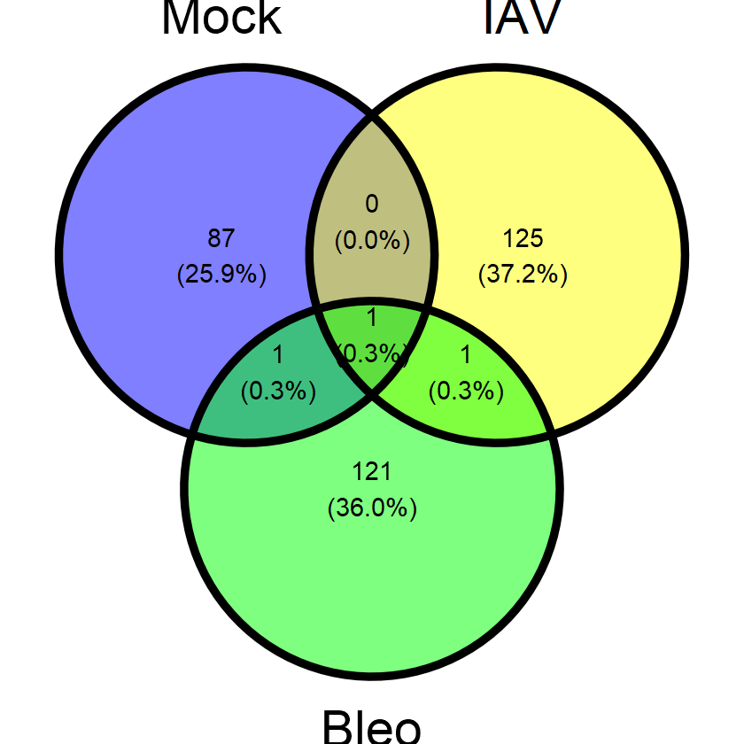

```r
library(ggvenn)

ggvenn(cutrun_venn_data, c('Mock', 'IAV', 'Bleo'), stroke_size = 2, set_name_size = 12, text_size = 6)

png(file = 'cutrun_venn_diagram_DE_peaks_genes.png', width = 1000, height = 1000)
ggvenn(cutrun_venn_data, c('Mock', 'IAV', 'Bleo'), stroke_size = 2, set_name_size = 12, text_size = 8)
dev.off()
```

**png:** 2

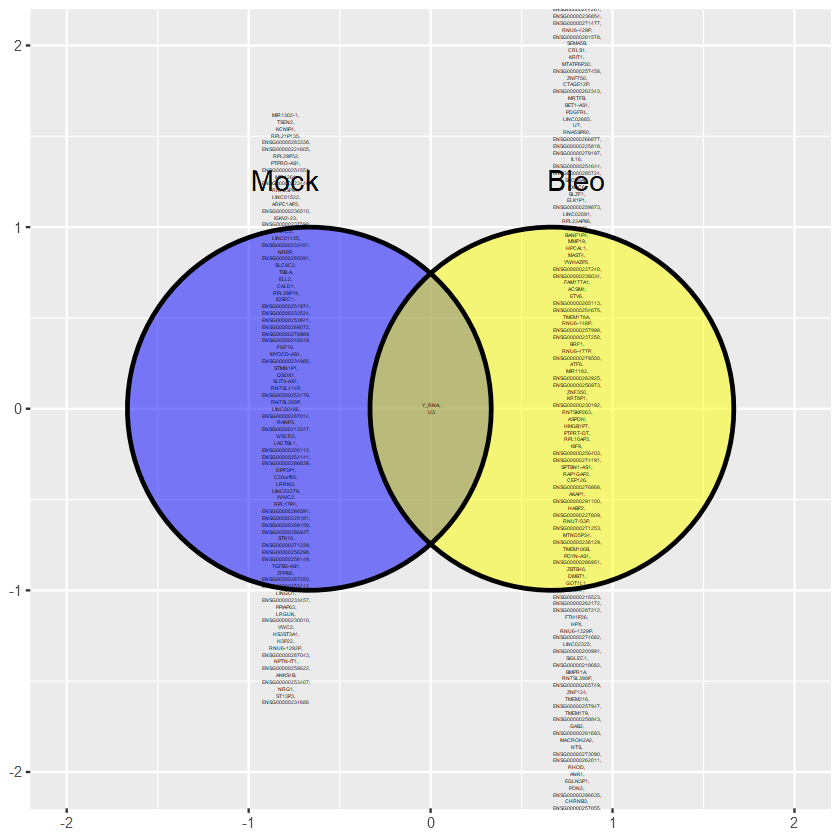

```r
#?geom_venn

ggplot(cutrun_venn_data) + geom_venn(aes(A = Mock, B = Bleo, label = genes), label_sep = ',\n ', text_size = 1, show_outside = 'none')

png(file = 'cutrun_venn_DE_mock_bleo.png', width = 1000, height = 1000)
ggplot(cutrun_venn_data) + geom_venn(aes(A = Mock, B = Bleo, label = genes), label_sep = ',\n ', text_size = 2, show_outside = 'none')
dev.off()
```

**png:** 2

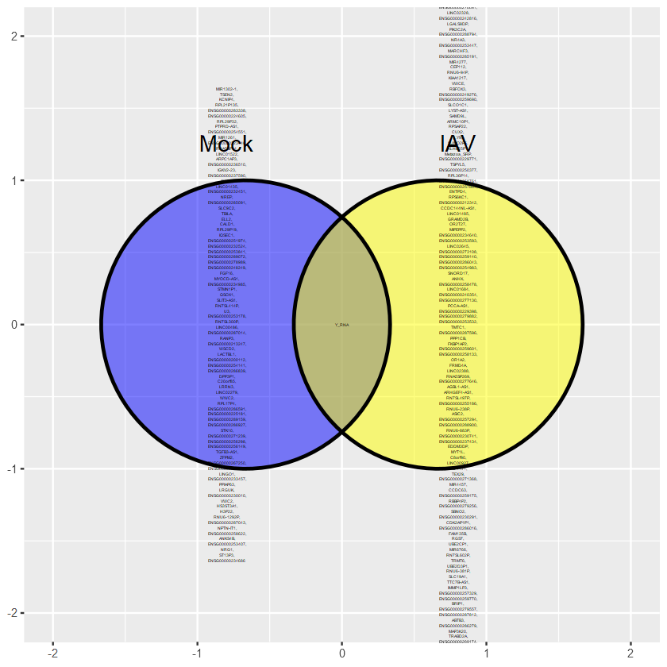

```r
ggplot(cutrun_venn_data) + geom_venn(aes(A = Mock, B = IAV, label = genes), label_sep = ',\n ', text_size = 1, show_outside = 'none')

png(file = 'cutrun_venn_DE_mock_iav.png', width = 1000, height = 1000)
ggplot(cutrun_venn_data) + geom_venn(aes(A = Mock, B = IAV, label = genes), label_sep = ',\n ', text_size = 2, show_outside = 'none')
dev.off()
```

**png:** 2

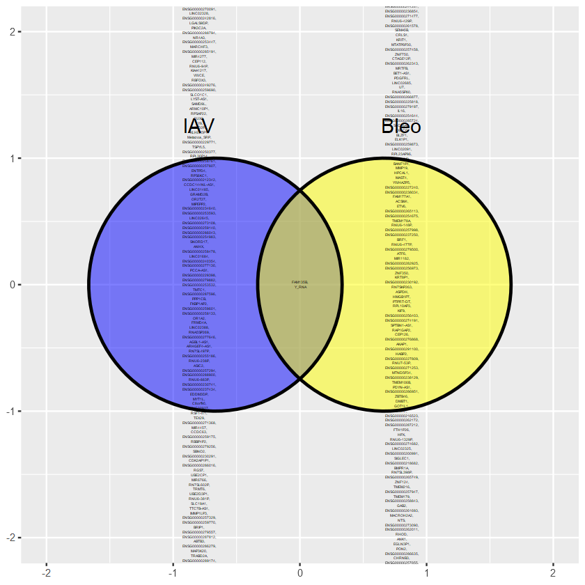

```r
ggplot(cutrun_venn_data) + geom_venn(aes(A = IAV, B = Bleo, label = genes), label_sep = ',\n ', text_size = 1, show_outside = 'none')

png(file = 'cutrun_venn_DE_iav_bleo.png', width = 1000, height = 1000)
ggplot(cutrun_venn_data) + geom_venn(aes(A = IAV, B = Bleo, label = genes), label_sep = ',\n ', text_size = 2, show_outside = 'none')
dev.off()
```

### comparison between RNA-Seq and Cut&Run

```r
# these are the gene names in the cut&run data
length(unique_gene_names)

# these are the gene names in the rna-seq data
length(unique_genes)

# adding all the genes to one list then making a unique list from that

all_genes_cutrun_rnaseq = c(unique_gene_names, unique_genes)

length(all_genes_cutrun_rnaseq)

# now only getting the unique names from this list

unique_cutrun_rnaseq_genes = NULL

for (x in c(1:length(all_genes_cutrun_rnaseq))){
    if (! all_genes_cutrun_rnaseq[x] %in% unique_cutrun_rnaseq_genes) unique_cutrun_rnaseq_genes = append(all_genes_cutrun_rnaseq[x], unique_cutrun_rnaseq_genes)
}

length(unique_cutrun_rnaseq_genes)

# this shows that there are no genes that overlapped meaning all the genes between the rna-seq and cut&run data were unique
# to each experiment.
# so i dont need to continue with the venn diagram
```

336

89

425

425